# Assignment - 1 - Machine Learning

Hanssic kennady

2022-08-23

## Import Library

```r
library(ISLR)
library(tidyverse)
```

## 1. This exercise involves the Auto data set studied in the lab. Make sure that the missing values have been removed from the data.

```r
data <- data.frame(Auto)
data
```

```
##      mpg cylinders displacement horsepower weight acceleration year origin
## 1   18.0         8        307.0        130   3504         12.0   70      1
## 2   15.0         8        350.0        165   3693         11.5   70      1
## 3   18.0         8        318.0        150   3436         11.0   70      1
## 4   16.0         8        304.0        150   3433         12.0   70      1
## 5   17.0         8        302.0        140   3449         10.5   70      1
## 6   15.0         8        429.0        198   4341         10.0   70      1
## 7   14.0         8        454.0        220   4354          9.0   70      1
## 8   14.0         8        440.0        215   4312          8.5   70      1
## 9   14.0         8        455.0        225   4425         10.0   70      1
## 10  15.0         8        390.0        190   3850          8.5   70      1
## 11  15.0         8        383.0        170   3563         10.0   70      1
## 12  14.0         8        340.0        160   3609          8.0   70      1
## 13  15.0         8        400.0        150   3761          9.5   70      1
## 14  14.0         8        455.0        225   3086         10.0   70      1
```

[output cut: 771 more lines]

### (a) Which of the predictors are quantitative, and which are qualitative?

```r
ls(data)
```

```
## [1] "acceleration" "cylinders"    "displacement" "horsepower"   "mpg"
## [6] "name"         "origin"       "weight"       "year"
```

#### ANS: **Name, Cylinders, Origin** are qualitative in the auto data set

### (b) What is the range of each quantitative predictor? You can answer this using the range() function.

```r
# Quantitative data as quan
quan <- select(data , -name, -origin, -cylinders)
# Qualitative data as qual
qual <- select(data, name, origin, cylinders)
```

```r
lapply(quan, range)
```

```
## $mpg
## [1]  9.0 46.6
##
## $displacement
## [1]  68 455
##
## $horsepower
## [1]  46 230
##
## $weight
## [1] 1613 5140
##
## $acceleration
## [1]  8.0 24.8
##
## $year
## [1] 70 82
```

#### ANS: acceleration (8, 24.8), displacement (68, 455), horsepower (46, 230), mpg (9, 46.6), weight (1613, 5140), year (70, 82)

### (c) What is the mean and standard deviation of each quantitative predictor?

```r
print(toupper("mean for quantitative predictor"))
```

```
## [1] "MEAN FOR QUANTITATIVE PREDICTOR"
```

```r
unlist(lapply(quan, mean))
```

```
##          mpg displacement   horsepower       weight acceleration         year
##     23.44592    194.41199    104.46939   2977.58418     15.54133     75.97959
```

```r
print(toupper("standard deviation for quantitative predictor"))
```

```
## [1] "STANDARD DEVIATION FOR QUANTITATIVE PREDICTOR"
```

```r
unlist(lapply(quan, sd))
```

```
##          mpg displacement   horsepower       weight acceleration         year
##     7.805007   104.644004    38.491160   849.402560     2.758864     3.683737
```

### (d) Now remove the 10th through 85th observations. What is the range, mean, and standard deviation of each predictor in the subset of the data that remains?

```r
rm_data <- quan[-c(10:84), ]
rm_data
```

```
##      mpg displacement horsepower weight acceleration year
## 1   18.0          307        130   3504         12.0   70
## 2   15.0          350        165   3693         11.5   70
## 3   18.0          318        150   3436         11.0   70
## 4   16.0          304        150   3433         12.0   70
## 5   17.0          302        140   3449         10.5   70
## 6   15.0          429        198   4341         10.0   70
## 7   14.0          454        220   4354          9.0   70
## 8   14.0          440        215   4312          8.5   70
## 9   14.0          455        225   4425         10.0   70
## 86  13.0          350        175   4100         13.0   73
## 87  14.0          304        150   3672         11.5   73
## 88  13.0          350        145   3988         13.0   73
## 89  14.0          302        137   4042         14.5   73
## 90  15.0          318        150   3777         12.5   73
```

[output cut: 303 more lines]

```r
print(toupper("range of quantitative(-10 to -85)"))
```

```
## [1] "RANGE OF QUANTITATIVE(-10 TO -85)"
```

```r
lapply(rm_data,range)
```

```
## $mpg
## [1] 11.0 46.6
##
## $displacement
## [1]  68 455
##
## $horsepower
## [1]  46 230
##
## $weight
## [1] 1649 4997
##
## $acceleration
## [1]  8.5 24.8
##
## $year
## [1] 70 82
```

```r
print(toupper("mean of quantitative(-10 to -85)"))
```

```
## [1] "MEAN OF QUANTITATIVE(-10 TO -85)"
```

```r
unlist(lapply(rm_data,mean))
```

```
##          mpg displacement   horsepower       weight acceleration         year
##     24.36845    187.75394    100.95584   2939.64353     15.71830     77.13249
```

```r
print(toupper("standard deviation of quantitative(-10 to -85)"))
```

```
## [1] "STANDARD DEVIATION OF QUANTITATIVE(-10 TO -85)"
```

```r
unlist(lapply(rm_data,sd))
```

```
##          mpg displacement   horsepower       weight acceleration         year
##     7.880898    99.939488    35.895567   812.649629     2.693813     3.110026
```

#### ANS: **RANGE** mpg(11.0, 46.6), displacement(68, 455), horsepower(46, 230), weight(1649, 4997), acceleration(8.5, 24.8), year(70, 82) **MEAN** mpg(24.36845), displacement(187.75394), horsepower(100.95584), weight(2939.64353), acceleration(15.71830), year(77.13249) **STANDARD DEVIATION** mpg(7.880898), displacement(99.939488), horsepower(35.895567), weight(812.649629), acceleration(2.693813), year(3.110026)

### (e) Using the full data set, investigate the predictors graphically, using scatterplots or other tools of your choice. Create some plots highlighting the relationships among the predictors. Comment on your findings.

```r
library(PerformanceAnalytics)
```

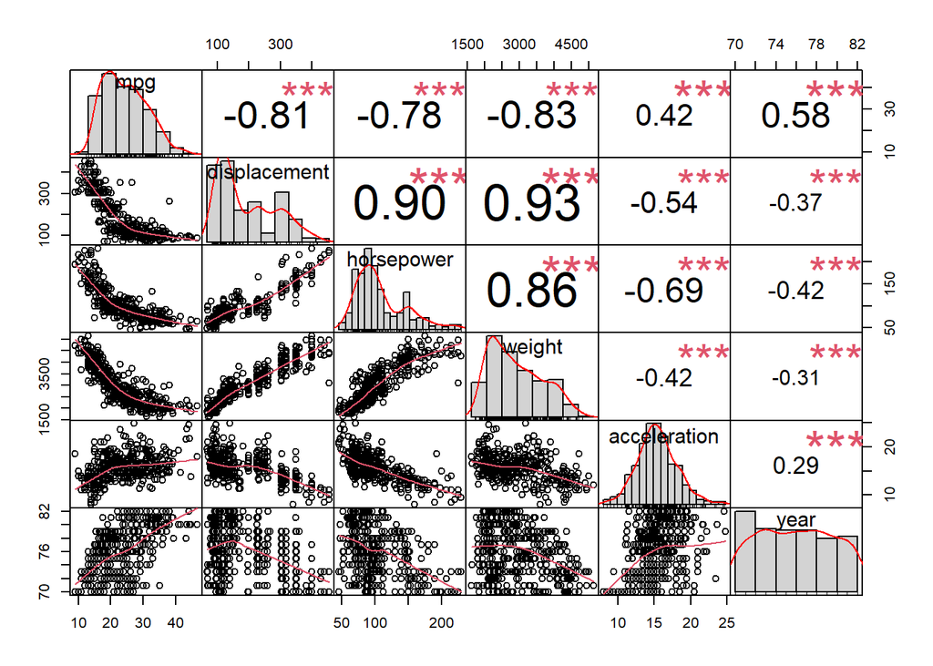

```r
chart.Correlation(quan, histogram = TRUE, method = "pearson")
```

```r
# pairs(data,upper.panel = NULL)
```